Read the data from the file containing the curves exported from UNICORN

```
## 'data.frame':    23 obs. of  30 variables:
##  $ LocalTime: Factor w/ 39 levels "11/12/2015 10:00:00 PM",..: 6 7 8 9 10 11 12 24 25 26 ...
##  $ WTG001   : num  -6.64 738.91 593.88 503.28 350.59 ...
##  $ WTG002   : num  -6.47 508.61 772.2 642.69 432.34 ...
##  $ WTG003   : num  -6.59 378.34 525.78 561.84 344.77 ...
##  $ WTG004   : num  -6.73 403.93 390.8 429.61 225.44 ...
##  $ WTG005   : num  -6.45 175.1 185.74 210.42 156.67 ...
##  $ WTG006   : num  0 843 743 648 441 ...
##  $ WTG007   : num  288 805 826 811 504 ...
##  $ WTG008   : num  -2.97 551.31 692.02 769.46 553.29 ...
##  $ WTG009   : num  38.8 748.6 678.5 642.3 514.1 ...
##  $ WTG010   : num  327 529 535 559 364 ...
##  $ WTG011   : num  306 472 525 440 315 ...
##  $ WTG012   : num  -5.53 263.42 581.41 693.55 474.95 ...
##  $ WTG013   : num  -7.2 229 474.3 537.8 435.9 ...
```

[output cut: 16 more lines]

```
##  [1] "WTG001" "WTG002" "WTG003" "WTG004" "WTG005" "WTG006" "WTG007"
##  [8] "WTG008" "WTG009" "WTG010" "WTG011" "WTG012" "WTG013" "WTG014"
## [15] "WTG015" "WTG016" "WTG017" "WTG018" "WTG019" "WTG020" "WTG021"
## [22] "WTG022" "WTG023" "WTG024" "WTG025" "WTG026" "WTG027" "WTG028"
## [29] "WTG029"
```

prepare the statistics data

```r
getCompassDirection=function(heading){
  if(heading>348.75 & heading <359.99)
    "N"
  else if(heading>=0 & heading <11.25)
    "N"
  else if(heading>11.25 & heading <33.75)
    "NNE"
  else if(heading>33.75 & heading <56.25)
    "NE"
  else if(heading>56.25 & heading <78.75)
    "ENE"
  else if(heading>78.75 & heading <101.25)
    "E"
  else if(heading>101.25 & heading <123.75)
    "ESE"
  else if(heading>123.75 & heading <146.25)
    "SE"
  else if(heading>146.25 & heading <168.75)
    "SSE"
  else if(heading>168.75 & heading <191.25)
    "S"
  else if(heading>191.25 & heading <213.75)
    "SSW"
  else if(heading>213.75 & heading <236.25)
    "SW"
  else if(heading>236.25 & heading <258.75)
    "WSW"
  else if(heading>258.75 & heading <281.25)
    "W"
  else if(heading>281.25 & heading <303.75)
    "WNW"
  else if(heading>303.75 & heading <326.25)
    "NW"
  else if(heading>326.25 & heading <348.75)
    "NNW"
}




tfpower=subset(turbineData,turbineData$Parameter=='Power'&turbineData$SystemName==curveIndexes[1])[4]
tfWindSpeed=subset(turbineData,turbineData$Parameter=='Wind speed'&turbineData$SystemName==curveIndexes[1])[4]
tfNacelle=  subset(turbineData,turbineData$Parameter=='Nacelle position'&turbineData$SystemName==curveIndexes[1])[4]
#add the compass directiuons for the Nacelle
tfCompassDirection=subset(turbineData,turbineData$Parameter=='Nacelle position'&turbineData$SystemName==curveIndexes[1])[4]

for(i in 1:29){
  tfpower[,curveIndexes[i]]=subset(turbineData,turbineData$Parameter=='Power'&turbineData$SystemName==curveIndexes1[i])[3]
  tfWindSpeed[,curveIndexes[i]]=subset(turbineData,turbineData$Parameter=='Wind speed'&turbineData$SystemName==curveIndexes1[i])[3]
  tfNacelle[,curveIndexes[i]]=subset(turbineData,turbineData$Parameter=='Nacelle position'&turbineData$SystemName==curveIndexes1[i])[3]

}

#add the compass direction
for(i in 1:29){

  tfCompassDirection[,curveIndexes[i]]=sapply(tfNacelle[,curveIndexes[i]],getCompassDirection)

}



tfpower=tfpower[,c(2:30)]
tfpower=tfpower[curveOperatingPoints,]

tfNacelle=tfNacelle[,c(2:30)]
tfNacelle=tfNacelle[curveOperatingPoints,]

tfWindSpeed=tfWindSpeed[,c(2:30)]
tfWindSpeed=tfWindSpeed[curveOperatingPoints,]

tfCompassDirection=tfCompassDirection[,c(2:30)]
tfCompassDirection=tfCompassDirection[curveOperatingPoints,]

curveNames=names(tfpower)
```

## Summary Statistics

Some of the userful stats from the data are max,min power, avg power, avg wind direction, max-min wind direction

```r
turbineSummaryMat=matrix(1:29*4,nrow=29,ncol=4)
rownames(turbineSummaryMat) <- curveNames[1:29]
colnames(turbineSummaryMat)<-c("maxWindSpeed","minWindSpeed","maxNacAngle","minNacAngle")
turbineSummary=as.data.frame(turbineSummaryMat)
turbineSummary$maxWindSpeed=sapply(tfWindSpeed,max)
turbineSummary$minWindSpeed=sapply(tfWindSpeed,min)
turbineSummary$maxNacAngle=sapply(tfNacelle,max)
turbineSummary$minNacAngle=sapply(tfNacelle,min)
turbineSummary$spreadNacAngle=turbineSummary$maxNacAngle-turbineSummary$minNacAngle


windDirections=rep(0,29)
for ( i in 1:29)
{
  windDirections[i]=names(sort(table(sapply(tfNacelle[,i],getCompassDirection)),decreasing = TRUE)[1])
}

turbineSummary$windDirection=as.factor(windDirections)
turbineSummary$maxPower=sapply(tfpower,max)
turbineSummary$minPower=sapply(tfpower,min)
turbineSummary$avgPower=sapply(tfpower,mean)
turbineSummary$totalPower=sapply(tfpower,sum)
str(turbineSummary)
```

```
## 'data.frame':    29 obs. of  10 variables:
##  $ maxWindSpeed  : num  7.56 7.58 6.73 6.01 4.83 ...
##  $ minWindSpeed  : num  2.92 2.6 2.58 2.96 2.23 ...
##  $ maxNacAngle   : num  90 55 99 99 247 ...
##  $ minNacAngle   : num  59 31 68 59.5 202.3 ...
##  $ spreadNacAngle: num  31 24 31 39.5 44.7 ...
##  $ windDirection : Factor w/ 11 levels "E","ENE","NE",..: 2 3 1 1 10 3 1 10 2 3 ...
##  $ maxPower      : num  739 772 562 430 210 ...
##  $ minPower      : num  -6.64 -6.47 -6.59 -6.73 -7.19 ...
##  $ avgPower      : num  293.5 254.2 187.7 175.2 75.8 ...
##  $ totalPower    : num  6751 5847 4317 4029 1743 ...
```

**Correlation Matrix** Now calculate the correlation matrix. This matrix will be the major source for similarity comparison If using the two curves we draw a plot then the correlation plots should be around a 45 degree line passing through the origin. Perfect correlation will occur if the two curves are same

```
##           WTG001    WTG002    WTG003    WTG004    WTG005    WTG006
## WTG001 1.0000000 0.7661959 0.7258720 0.8255450 0.7569940 0.9010416
## WTG002 0.7661959 1.0000000 0.9462258 0.8041986 0.8130271 0.8519315
##           WTG007    WTG008    WTG009    WTG010    WTG011    WTG012
## WTG001 0.8590909 0.7512345 0.9179888 0.6614410 0.6168335 0.5143311
## WTG002 0.8912912 0.9512885 0.8798751 0.8666399 0.7972555 0.8936756
##           WTG013    WTG014    WTG015    WTG016    WTG017    WTG018
## WTG001 0.5801658 0.5503939 0.7586742 0.6724674 0.6996575 0.8556745
## WTG002 0.9116875 0.9228449 0.7768364 0.9547538 0.8803806 0.9429855
##           WTG019    WTG020    WTG021    WTG022    WTG023    WTG024
## WTG001 0.7315425 0.6855122 0.4922201 0.6486746 0.5829703 0.7043087
## WTG002 0.9758861 0.9223353 0.9001824 0.9016076 0.9119039 0.9155762
##           WTG025    WTG026    WTG027    WTG028    WTG029
## WTG001 0.6766581 0.6679623 0.5442665 0.7033741 0.6865556
## WTG002 0.9351954 0.9453737 0.8824230 0.9069175 0.9275643
```

Now we need to remove the entries which are too much differnet. Currently we are setting the similarity score to be minimum of 0.96

we can have a small function where we enter the name of the chromatogram and get back the similarities

** Plotting the Similar Curves ** Now in order to draw plots between the chromatograms which fall above .96 similarity we use the filtered list that we created earlier

**Computational Parameters** *IN order to verify our correlations we need to take another calculations. Eucleadian distance measures how far two points are on a the eucleadian plot. We will have to consider all the points on the curves to get teh distance. If the two curves are similar than there will not be huge distance between two points corresponding to two curves. (Note we are assuming that total number of points are same on both teh curves)

*Another measure is the Area under the curves. It cannot tell you if the two curves are similar on its own since the two curves can be dissimilar but may have peaks which if calculated the Area dunder will compute out to be same. Area under the curve si useful other way rounf just like the eucleadian distance. You will know that the two curves are similar based on the correlation, bu t now you jsut want to verify if the correlation is predicting the correct status. Area under the curve simialr will show that the total yield is simialr.

Eucledian distance calculation

Print the list of the curves

Test data

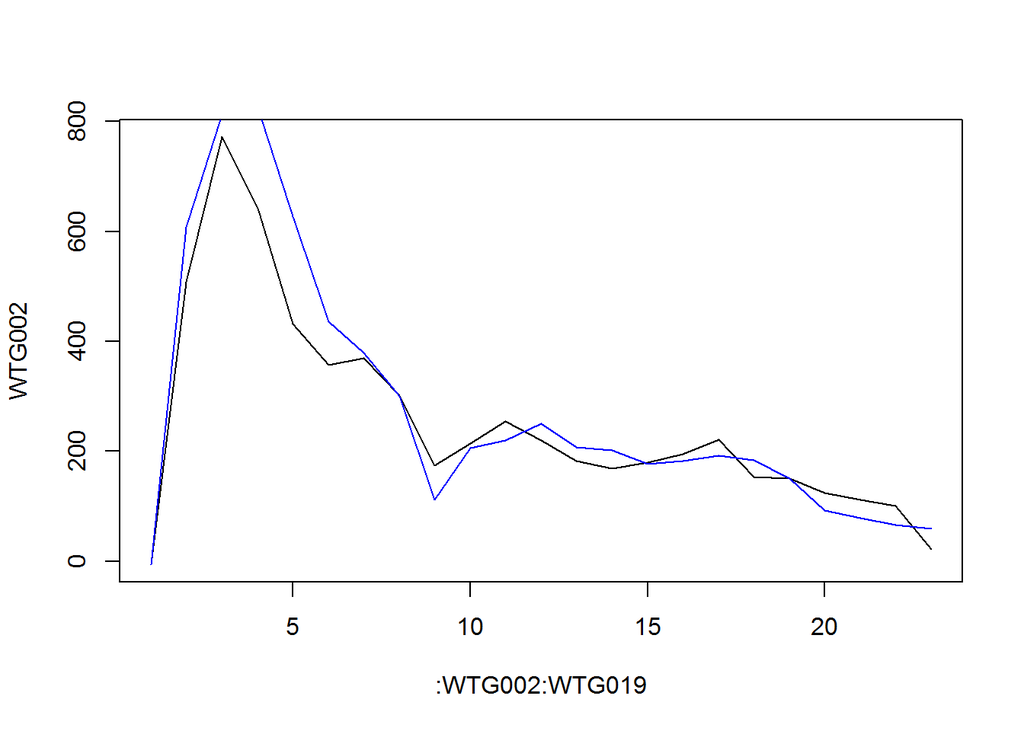

```
##               WTG002       WTG019
## Eucledian       0.00    0.3273840
## Peak Area    5846.87 6362.4042910
## PeakArea Var    0.00    8.8172752
## Correlation     1.00    0.9758861
##        maxWindSpeed minWindSpeed maxNacAngle minNacAngle spreadNacAngle
## WTG002     7.582446     2.600021    55.00047    31.00027       24.00020
## WTG019     7.649612     2.548343    50.00042    13.00011       37.00031
##        windDirection maxPower  minPower avgPower totalPower
## WTG002            NE 772.2020 -6.467360 254.2117   5846.870
## WTG019            NE 825.0233 -6.513079 276.6263   6362.404
## -----------------------------------------
```

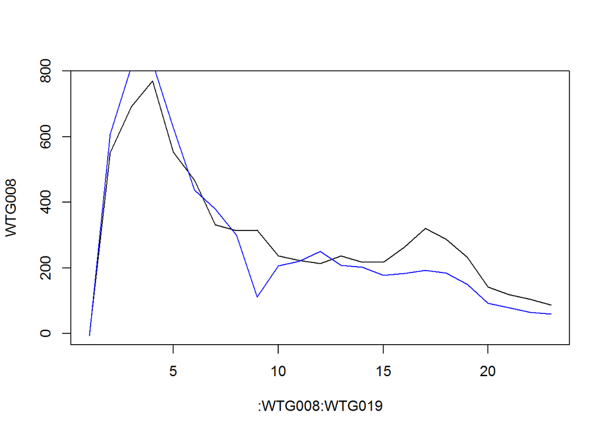

```
##               WTG008       WTG019
## Eucledian       0.00    0.4424048
## Peak Area    6886.76 6362.4042910
## PeakArea Var    0.00    7.6139729
## Correlation     1.00    0.9635333
##        maxWindSpeed minWindSpeed maxNacAngle minNacAngle spreadNacAngle
## WTG008     7.604816     3.341882   222.26620   194.16990       28.09630
## WTG019     7.649612     2.548343    50.00042    13.00011       37.00031
##        windDirection maxPower  minPower avgPower totalPower
## WTG008            SW 769.4644 -2.966351 299.4244   6886.760
## WTG019            NE 825.0233 -6.513079 276.6263   6362.404
## -----------------------------------------
```

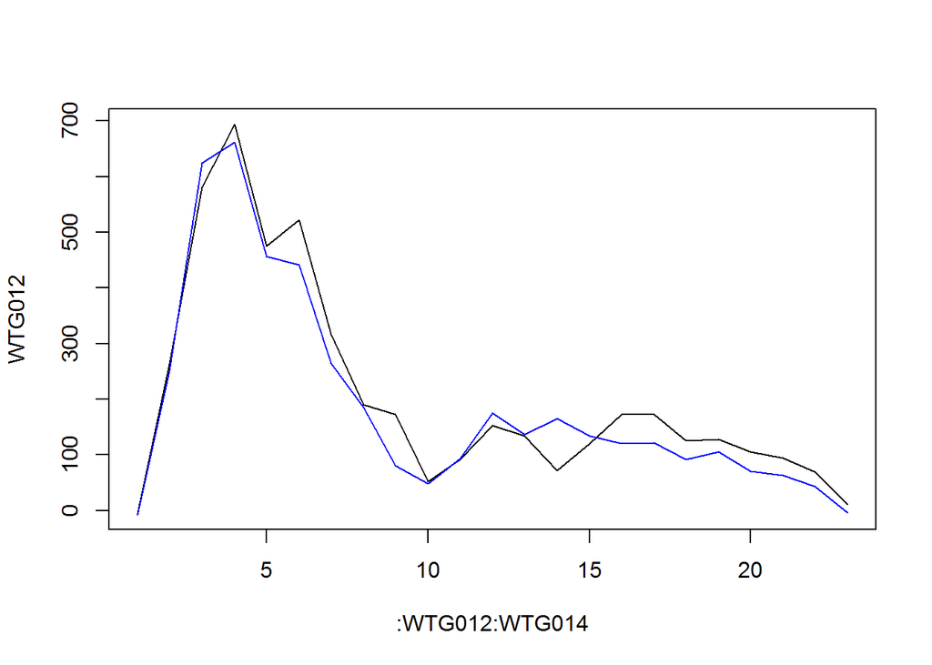

```
##               WTG012       WTG014
## Eucledian       0.00    0.2745384
## Peak Area    4708.37 4320.7241500
## PeakArea Var    0.00    8.2331165
## Correlation     1.00    0.9780719
##        maxWindSpeed minWindSpeed maxNacAngle minNacAngle spreadNacAngle
## WTG012     6.971401     2.742454    348.0029   318.00270       30.00020
## WTG014     5.213290     1.701007    107.0009    78.36178       28.63912
##        windDirection maxPower  minPower avgPower totalPower
## WTG012           NNW 693.5535 -5.526756 204.7117   4708.370
## WTG014             E 661.8846 -7.490030 187.8576   4320.724
## -----------------------------------------
```

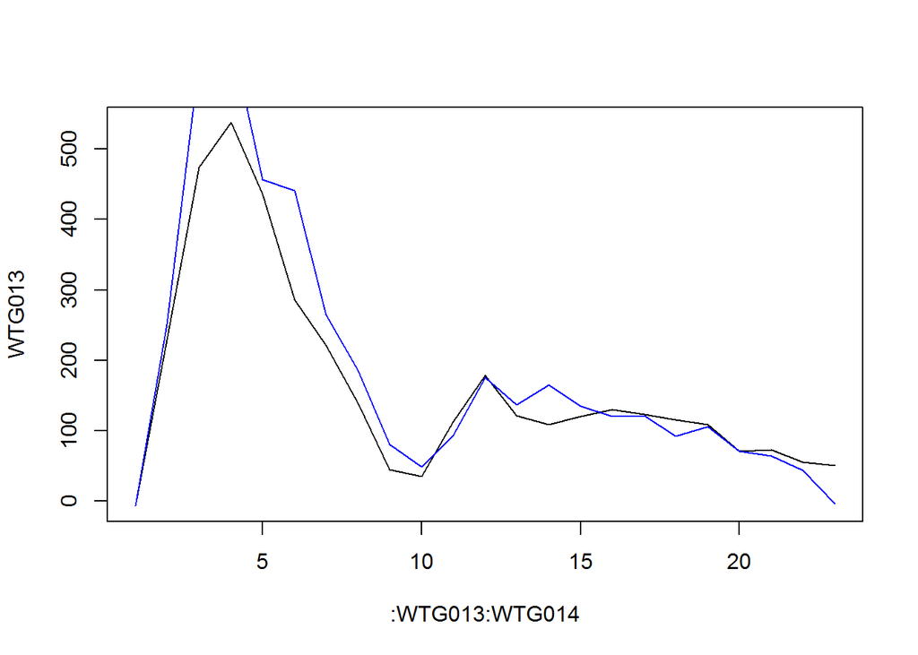

```
##                WTG013       WTG014
## Eucledian       0.000    0.2823755
## Peak Area    3762.095 4320.7241500
## PeakArea Var    0.000   14.8488827
## Correlation     1.000    0.9798587
##        maxWindSpeed minWindSpeed maxNacAngle minNacAngle spreadNacAngle
## WTG013     6.282269     2.532226    41.00035     3.89896       37.10139
## WTG014     5.213290     1.701007   107.00090    78.36178       28.63912
##        windDirection maxPower  minPower avgPower totalPower
## WTG013           NNE 537.8001 -7.201982 163.5694   3762.095
## WTG014             E 661.8846 -7.490030 187.8576   4320.724
## -----------------------------------------
```

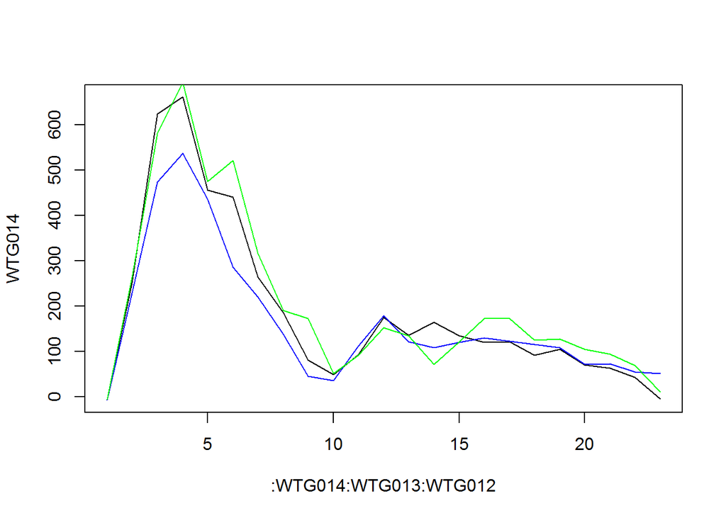

```
##                WTG014       WTG013       WTG012
## Eucledian       0.000    0.2823755    0.2745384
## Peak Area    4320.724 3762.0950680 4708.3697140
## PeakArea Var    0.000   12.9290615    8.9717730
## Correlation     1.000    0.9798587    0.9780719
##        maxWindSpeed minWindSpeed maxNacAngle minNacAngle spreadNacAngle
## WTG014     5.213290     1.701007   107.00090    78.36178       28.63912
## WTG013     6.282269     2.532226    41.00035     3.89896       37.10139
## WTG012     6.971401     2.742454   348.00290   318.00270       30.00020
##        windDirection maxPower  minPower avgPower totalPower
## WTG014             E 661.8846 -7.490030 187.8576   4320.724
## WTG013           NNE 537.8001 -7.201982 163.5694   3762.095
## WTG012           NNW 693.5535 -5.526756 204.7117   4708.370
## -----------------------------------------
```

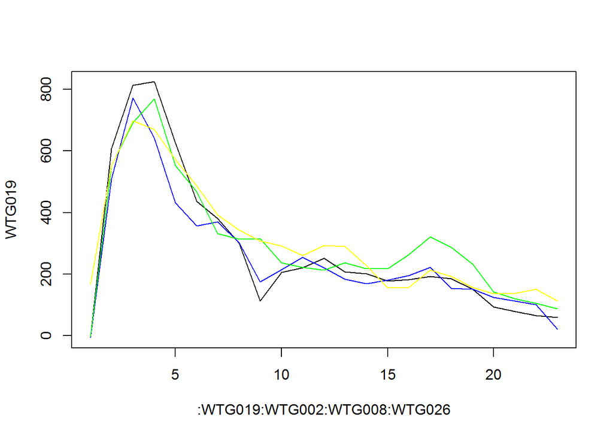

```
##                WTG019       WTG002       WTG008       WTG026
## Eucledian       0.000    0.3273840    0.4424048    0.3946855
## Peak Area    6362.404 5846.8697000 6886.7603590 6958.7671000
## PeakArea Var    0.000    8.1028267    8.2414767    9.3732303
## Correlation     1.000    0.9758861    0.9635333    0.9630613
##        maxWindSpeed minWindSpeed maxNacAngle minNacAngle spreadNacAngle
## WTG019     7.649612     2.548343    50.00042    13.00011       37.00031
## WTG002     7.582446     2.600021    55.00047    31.00027       24.00020
## WTG020     6.504207     2.569202    60.00051    29.00977       30.99074
## WTG018     6.774032     2.767410   162.00140   134.00120       28.00020
## WTG008     7.604816     3.341882   222.26620   194.16990       28.09630
## WTG026     7.075254     3.489158   107.00090    76.50394       30.49696
##        windDirection maxPower   minPower avgPower totalPower
## WTG019            NE 825.0233  -6.513079 276.6263   6362.404
## WTG002            NE 772.2020  -6.467360 254.2117   5846.870
## WTG020            NE 574.5320  -6.479968 206.0273   4738.628
## WTG018           SSE 622.8696  -2.119621 221.4299   5092.889
## WTG008            SW 769.4644  -2.966351 299.4244   6886.760
## WTG026             E 697.7652 112.776600 302.5551   6958.767
## -----------------------------------------
```

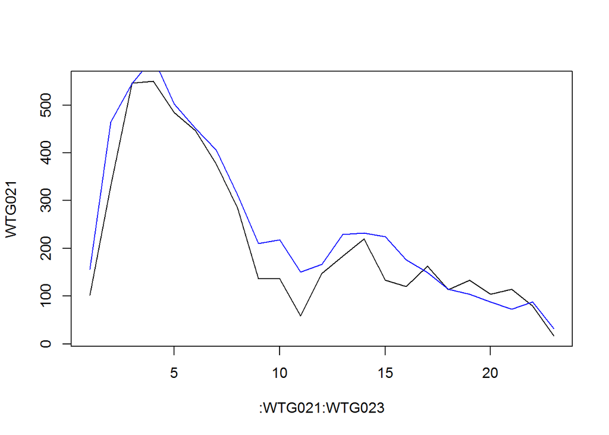

```
##                WTG021       WTG023
## Eucledian       0.000    0.3679902
## Peak Area    4980.198 5691.7571200
## PeakArea Var    0.000   14.2877665
## Correlation     1.000    0.9653485
##        maxWindSpeed minWindSpeed maxNacAngle minNacAngle spreadNacAngle
## WTG021     6.695724     2.496529    49.21767    23.00019       26.21748
## WTG023     6.704882     2.637646   328.00290   304.00270       24.00020
##        windDirection maxPower minPower avgPower totalPower
## WTG021            NE 549.4333 16.69121 216.5303   4980.198
## WTG023            NW 599.1721 32.45296 247.4677   5691.757
## -----------------------------------------
```

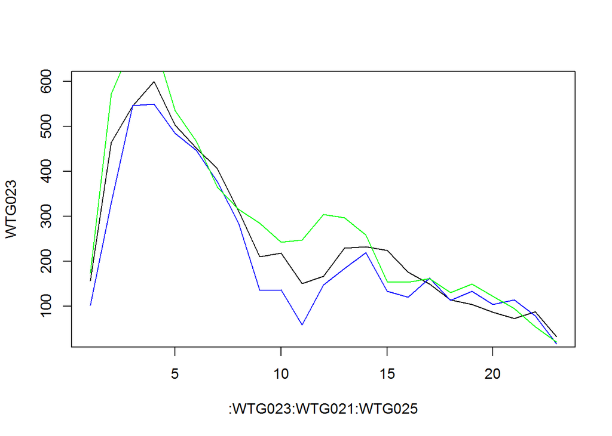

```
##                WTG023       WTG021       WTG025
## Eucledian       0.000    0.3679902    0.3737317
## Peak Area    5691.757 4980.1980500 6476.9900700
## PeakArea Var    0.000   12.5015712   13.7959673
## Correlation     1.000    0.9653485    0.9628097
##        maxWindSpeed minWindSpeed maxNacAngle minNacAngle spreadNacAngle
## WTG023     6.704882     2.637646   328.00290   304.00270       24.00020
## WTG027     6.062472     3.148946    88.00074    56.27060       31.73014
## WTG021     6.695724     2.496529    49.21767    23.00019       26.21748
## WTG025     6.917037     2.755959   195.00160   174.00150       21.00010
##        windDirection maxPower minPower avgPower totalPower
## WTG023            NW 599.1721 32.45296 247.4677   5691.757
## WTG027           ENE 400.2786 26.50290 171.0233   3933.537
## WTG021            NE 549.4333 16.69121 216.5303   4980.198
## WTG025           SSW 690.7410 20.72142 281.6083   6476.990
## -----------------------------------------
```

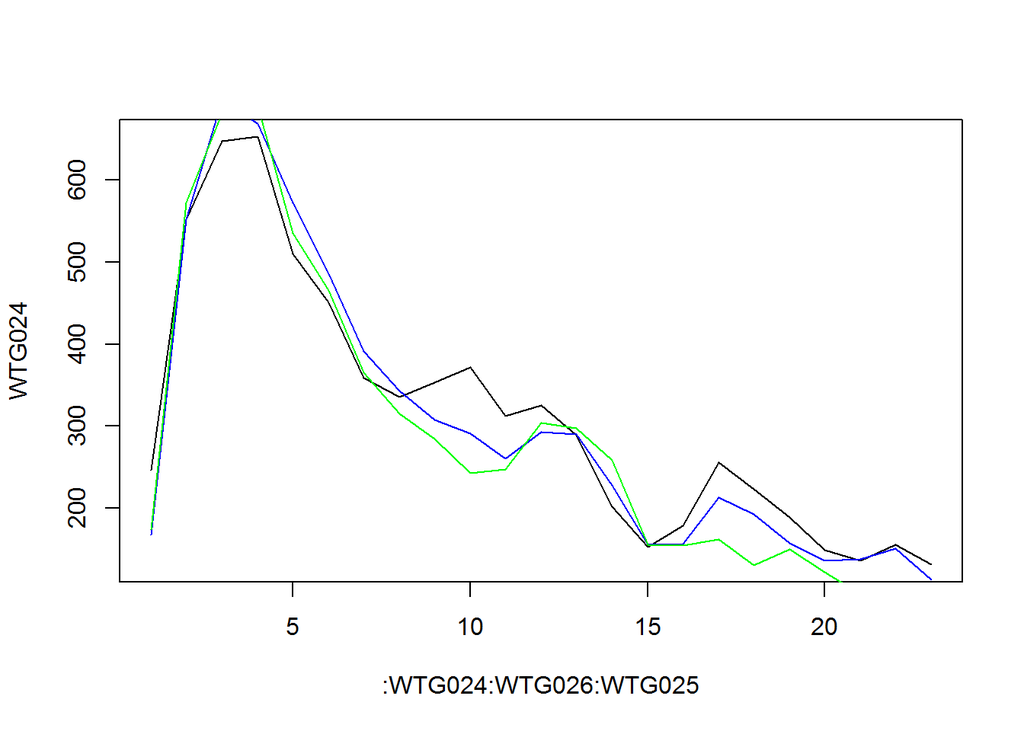

```
##                WTG024       WTG026       WTG025
## Eucledian       0.000    0.2971942    0.4031050
## Peak Area    7177.014 6958.7671000 6476.9900700
## PeakArea Var    0.000    3.0409124    9.7536907
## Correlation     1.000    0.9811507    0.9704061
##        maxWindSpeed minWindSpeed maxNacAngle minNacAngle spreadNacAngle
## WTG024     7.385052     3.838647    138.0012   107.22670       30.77450
## WTG026     7.075254     3.489158    107.0009    76.50394       30.49696
## WTG025     6.917037     2.755959    195.0016   174.00150       21.00010
##        windDirection maxPower  minPower avgPower totalPower
## WTG024            SE 652.9548 130.90010 312.0441   7177.014
## WTG026             E 697.7652 112.77660 302.5551   6958.767
## WTG025           SSW 690.7410  20.72142 281.6083   6476.990
## -----------------------------------------
```

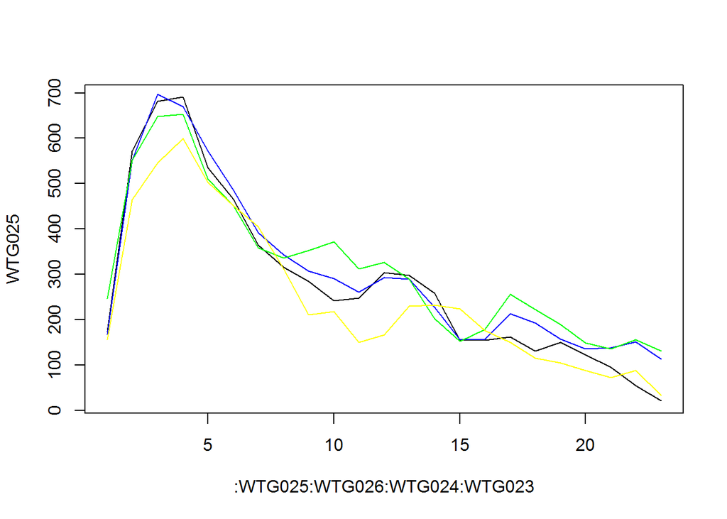

```
##               WTG025       WTG026       WTG024       WTG023
## Eucledian       0.00    0.3975053    0.4031050    0.3737317
## Peak Area    6476.99 6958.7671000 7177.0138000 5691.7571200
## PeakArea Var    0.00    7.4382858   10.8078555   12.1234237
## Correlation     1.00    0.9860113    0.9704061    0.9628097
##        maxWindSpeed minWindSpeed maxNacAngle minNacAngle spreadNacAngle
## WTG025     6.917037     2.755959   195.00160   174.00150       21.00010
## WTG026     7.075254     3.489158   107.00090    76.50394       30.49696
## WTG024     7.385052     3.838647   138.00120   107.22670       30.77450
## WTG029     7.171709     4.158792    35.00029    14.05956       20.94073
## WTG022     6.591738     3.048939    44.97645    16.81277       28.16368
## WTG023     6.704882     2.637646   328.00290   304.00270       24.00020
##        windDirection maxPower  minPower avgPower totalPower
## WTG025           SSW 690.7410  20.72142 281.6083   6476.990
## WTG026             E 697.7652 112.77660 302.5551   6958.767
## WTG024            SE 652.9548 130.90010 312.0441   7177.014
## WTG029           NNE 697.3801 114.34900 326.3426   7505.879
## WTG022            NE 477.6747  31.45433 210.3501   4838.052
## WTG023            NW 599.1721  32.45296 247.4677   5691.757
## -----------------------------------------
```

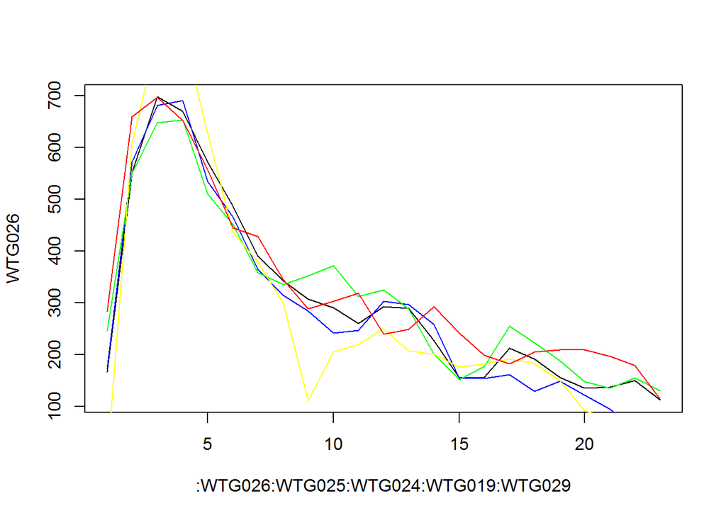

```
##                WTG026       WTG025       WTG024       WTG019       WTG029
## Eucledian       0.000    0.3975053    0.2971942    0.3946855    0.4313821
## Peak Area    6958.767 6476.9900700 7177.0138000 6362.4042910 7505.8790000
## PeakArea Var    0.000    6.9233102    3.1362840    8.5699493    7.8621959
## Correlation     1.000    0.9860113    0.9811507    0.9630613    0.9621928
##        maxWindSpeed minWindSpeed maxNacAngle minNacAngle spreadNacAngle
## WTG026     7.075254     3.489158   107.00090    76.50394       30.49696
## WTG025     6.917037     2.755959   195.00160   174.00150       21.00010
## WTG024     7.385052     3.838647   138.00120   107.22670       30.77450
## WTG019     7.649612     2.548343    50.00042    13.00011       37.00031
## WTG029     7.171709     4.158792    35.00029    14.05956       20.94073
##        windDirection maxPower   minPower avgPower totalPower
## WTG026             E 697.7652 112.776600 302.5551   6958.767
## WTG025           SSW 690.7410  20.721420 281.6083   6476.990
## WTG024            SE 652.9548 130.900100 312.0441   7177.014
## WTG019            NE 825.0233  -6.513079 276.6263   6362.404
## WTG029           NNE 697.3801 114.349000 326.3426   7505.879
## -----------------------------------------
```

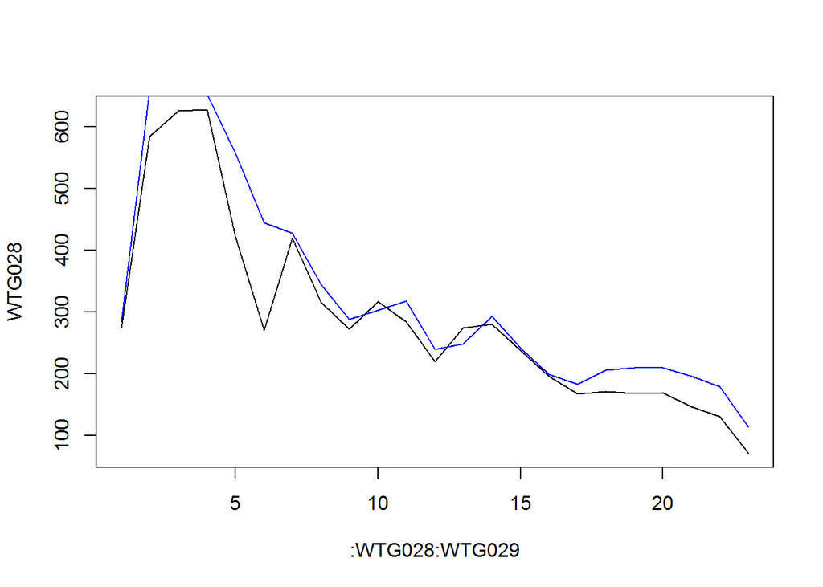

```
##                WTG028       WTG029
## Eucledian       0.000    0.3772731
## Peak Area    6657.688 7505.8790000
## PeakArea Var    0.000   12.7400278
## Correlation     1.000    0.9654171
##        maxWindSpeed minWindSpeed maxNacAngle minNacAngle spreadNacAngle
## WTG028     6.915547     3.609384   351.00310   325.42970       25.57340
## WTG029     7.171709     4.158792    35.00029    14.05956       20.94073
##        windDirection maxPower  minPower avgPower totalPower
## WTG028           NNW 627.6813  71.59113 289.4647   6657.688
## WTG029           NNE 697.3801 114.34900 326.3426   7505.879
## -----------------------------------------
```

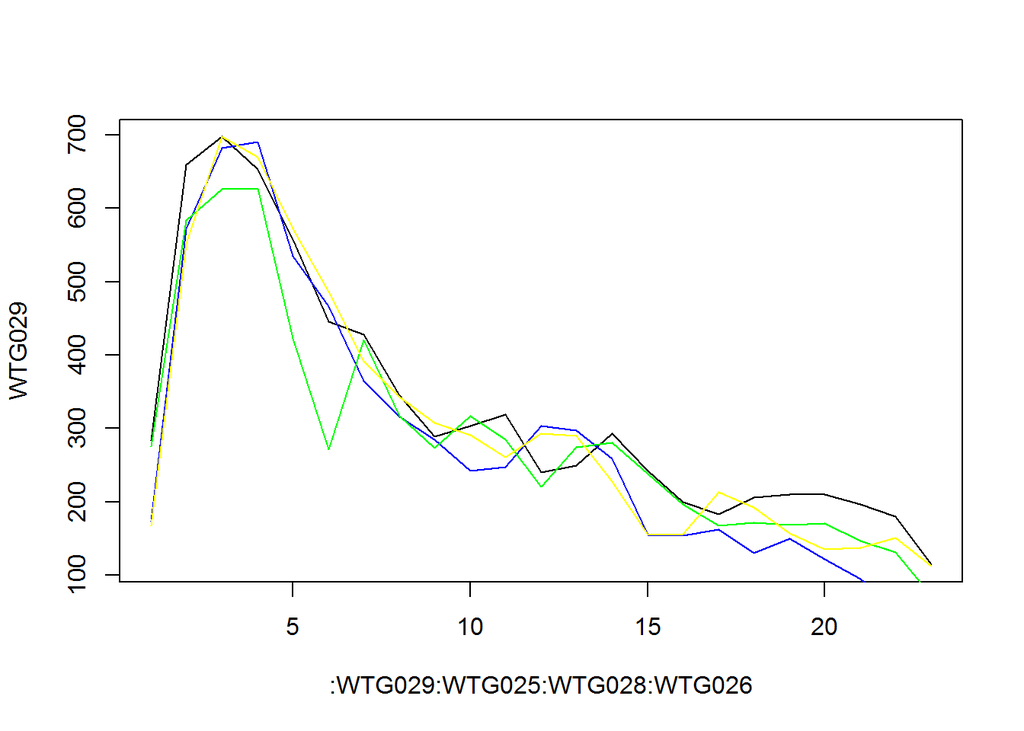

```
##                WTG029       WTG025       WTG028       WTG026
## Eucledian       0.000    0.3732919    0.3772731    0.4313821
## Peak Area    7505.879 6476.9900700 6657.6877300 6958.7671000
## PeakArea Var    0.000   13.7077740   11.3003590    7.2891116
## Correlation     1.000    0.9656730    0.9654171    0.9621928
##        maxWindSpeed minWindSpeed maxNacAngle minNacAngle spreadNacAngle
## WTG029     7.171709     4.158792    35.00029    14.05956       20.94073
## WTG025     6.917037     2.755959   195.00160   174.00150       21.00010
## WTG028     6.915547     3.609384   351.00310   325.42970       25.57340
## WTG026     7.075254     3.489158   107.00090    76.50394       30.49696
##        windDirection maxPower  minPower avgPower totalPower
## WTG029           NNE 697.3801 114.34900 326.3426   7505.879
## WTG025           SSW 690.7410  20.72142 281.6083   6476.990
## WTG028           NNW 627.6813  71.59113 289.4647   6657.688
## WTG026             E 697.7652 112.77660 302.5551   6958.767
## -----------------------------------------
```